# ECON4110 - DATA EXPLORATION PROJECT

Author

Hanah Nguyen

# Introduction

*Purpose:* This project navigates the effect of the release of the U.S Department of Education’s College Scorecard in September 2015 on high-earnings colleges.

*Goal:* Understand whether this public release of earnings data influenced students’ behavior on certain types of colleges.

*Approach:* Using difference-in-difference regression models with interaction terms, this project explores whether colleges with higher or lower post-graduate earnings experienced different changes in search interest following the Scorecard’s launch.

# Exploratory Data Analysis

After exploring the final_data_clean set, I decide to keep these columns like below and do some research such as datatypes, NULL values to convert them into proper format for further analysis.

```r
# load final_data from Data Clean Up
final_data_clean = import("clean/final_data_clean.rds",trust=TRUE)

# keep these columns for future analysis
final_data_clean2 = final_data_clean %>%
  select(schid,schname, index, index_z,date, month, `md_earn_wne_p10-REPORTED-EARNINGS`, CONTROL, PCTPELL, UGDS,UGDS_WHITE,SAT_AVG, LOCALE)

# convert md_earn_wne_p10_REPORTED_EARNINGS to numeric
## Replace 20463 PrivacySuppressed and 55524 NULL values with NA
final_data_clean2$`md_earn_wne_p10-REPORTED-EARNINGS` = na_if(final_data_clean2$`md_earn_wne_p10-REPORTED-EARNINGS`, "PrivacySuppressed")

final_data_clean2$`md_earn_wne_p10-REPORTED-EARNINGS` = na_if(final_data_clean2$`md_earn_wne_p10-REPORTED-EARNINGS`, "NULL")

## Check if the data still has "PrivacySuppressed" and "NULL"
sum(final_data_clean2$`md_earn_wne_p10-REPORTED-EARNINGS`=="PrivacySuppressed",na.rm = TRUE)
```

```
[1] 0
```

```r
## convert the column to numeric
final_data_clean2$`md_earn_wne_p10-REPORTED-EARNINGS` = as.numeric(final_data_clean2$`md_earn_wne_p10-REPORTED-EARNINGS`)
```

Next, I will classify high and low-earnings colleges. Any values under the median will be classified as low, and above the median will be high-earnings. 1 will indicate high-earnings colleges, and 0 will indicate low-earnings colleges.

```r
# create high and low-earnings dummy variables
final_data_clean2$high_earnings= ifelse(final_data_clean2$`md_earn_wne_p10-REPORTED-EARNINGS` >=median(final_data_clean2$`md_earn_wne_p10-REPORTED-EARNINGS`,na.rm=TRUE),1,0)

# Create post-treatment dummy for post_scorecard effect
## date after 2015/09/15 is 1, before that is 0
final_data_clean2$post_scorecard <- ifelse(final_data_clean2$date >= as.Date("2015-09-01"), 1, 0)
```

# Analysis

## First regression

I first estimate the treatment effect of Google search interest on high-earnings colleges.

```r
# regress index_z on interaction term between post_scorecard*high_earnings
reg1 = feols(index_z ~ post_scorecard*high_earnings, data = final_data_clean2)
```

```
NOTE: 59,519 observations removed because of NA values (LHS: 4,543, RHS: 59,042).
```

```r
etable(reg1)
```

```
                                              reg1
Dependent Var.:                            index_z

Constant                        0.0294*** (0.0018)
post_scorecard                 -0.1567*** (0.0042)
high_earnings                   0.0158*** (0.0026)
post_scorecard x high_earnings -0.0845*** (0.0060)
______________________________ ___________________
S.E. type                                      IID
Observations                               730,954
R2                                         0.00635
Adj. R2                                    0.00634
---
Signif. codes: 0 '***' 0.001 '**' 0.01 '*' 0.05 '.' 0.1 ' ' 1
```

*Result:*

## Second regression

Next, I add some control variables to the model, such as schname and date.

```r
reg2 = feols(index_z ~ post_scorecard * high_earnings | schname + date, data = final_data_clean2)
```

```
NOTE: 59,519 observations removed because of NA values (LHS: 4,543, RHS: 59,042, Fixed-effects: 4,009).
```

```
The variables 'post_scorecard' and 'high_earnings' have been removed because of collinearity (see $collin.var).
```

```r
etable(reg2)
```

```
                                              reg2
Dependent Var.:                            index_z

post_scorecard x high_earnings -0.0833*** (0.0232)
Fixed-Effects:                 -------------------
schname                                        Yes
date                                           Yes
______________________________ ___________________
S.E.: Clustered                        by: schname
Observations                               730,954
R2                                         0.17644
Within R2                                  0.00032
---
Signif. codes: 0 '***' 0.001 '**' 0.01 '*' 0.05 '.' 0.1 ' ' 1
```

*Result:* After controlling for time-invariant school characteristics and overall time trends in search activity, the regression reveals that the introduction of the College Scorecard led to a statistically significant 0.0833 unit decrease with a standard error of 0.0232 in Google Trends search index for colleges with high-earning graduates compared to those with low-earning graduates. This suggests that the College Scorecard made graduate earnings information more prominent, resulting in decreased search interest for institutions with better earnings outcomes, beyond general search trends and pre-existing differences between colleges.

## Third regression

Lastly, I use the logarithm of median earnings to reduce the positive skewness and avoid potential heteroskedasticity. I estimate the effect of post_scorecard on index across colleges and how that effect varies by log_earnings, controlling for CONTROL (type of school: public vs private), and LOCALE (urban or rural areas).

```r
final_data_clean2$log_earnings = log(final_data_clean2$`md_earn_wne_p10-REPORTED-EARNINGS`)

reg3 = feols(index_z ~ post_scorecard * log_earnings + CONTROL + LOCALE, data = final_data_clean2)
```

```
NOTE: 59,519 observations removed because of NA values (LHS: 4,543, RHS: 59,042).
```

```r
etable(reg3)
```

```
                                             reg3
Dependent Var.:                           index_z

Constant                      -0.3405*** (0.0587)
post_scorecard                  1.821*** (0.1305)
log_earnings                   0.0355*** (0.0055)
CONTROL                         -5.32e-5 (0.0019)
LOCALE12                         -0.0001 (0.0039)
LOCALE13                         -0.0001 (0.0039)
LOCALE21                          1.2e-5 (0.0036)
LOCALE22                         9.67e-7 (0.0071)
LOCALE23                          0.0001 (0.0084)
LOCALE31                         -0.0001 (0.0068)
LOCALE32                        -5.85e-5 (0.0047)
LOCALE33                         9.92e-5 (0.0051)
LOCALE41                            3e-6 (0.0077)
LOCALE42                          0.0004 (0.0137)
LOCALE43                         -0.0002 (0.0129)
post_scorecard x log_earnings -0.1895*** (0.0122)
_____________________________ ___________________
S.E. type                                     IID
Observations                              730,954
R2                                        0.00640
Adj. R2                                   0.00638
---
Signif. codes: 0 '***' 0.001 '**' 0.01 '*' 0.05 '.' 0.1 ' ' 1
```

## Graph 1: Search Interest by Earning Groups Over Time

[figure not shown]

```r
plot_data = final_data_clean2 %>%
  group_by(date, high_earnings) %>%
  summarize(mean_index = mean(index, na.rm = TRUE),.groups ="drop")

ggplot(plot_data %>% filter(!is.na(high_earnings)), aes(x = as.Date(date), y = mean_index, color = factor(high_earnings))) +
  geom_line() +
  geom_vline(xintercept = as.Date("2015-09-1"), linetype = "dashed",color = "brown1", size = 0.8) +
  annotate("text", x = as.Date("2015-09-1"), y = max(plot_data$mean_index, na.rm = TRUE), label = "Sep 1, 2015",vjust =2 ,hjust = -0.1,color = "brown1",size = 4)+
  scale_color_manual(values = c("0" = "blue1", "1" = "brown1"))+
  labs(title = "Google Search Interest: High vs. Low Earnings Colleges Over Time",
       x = "Years",
       y = "Average Search Interest",
       color = "Earning Groups") +
  theme_minimal()+
  theme(axis.title.x = element_text(face="bold",family="serif"),
        axis.text.y = element_text(face = "bold",family="serif"),
        axis.text.x = element_text(face = "bold",family="serif"),
        title=element_text(face="bold",family="serif"),
        plot.title=element_text(hjust=0.5,face="bold",size=14)
        )
```

This graph demonstrates the average Google search interest over time for 2 groups of colleges: high and low-earning after graduation. Generally, people show a higher level of interest in colleges associated with higher post-graduation earnings compared to those with lower earnings over the years. The release of College Scorecard in September 2015 appears to narrow the gap between the two groups, suggesting a relative decrease in interest for high-earning colleges.

## Graph 2: Pre/Post Search Interest by Earnings Group

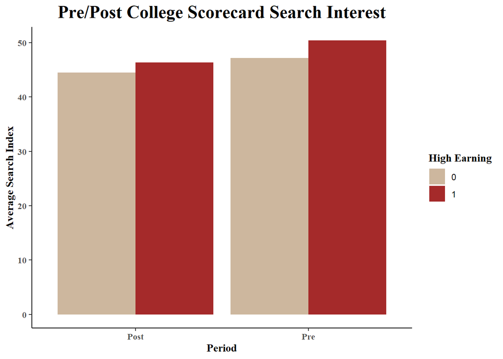

```r
final_data_clean2$period = ifelse(final_data_clean2$post_scorecard == 1, "Post", "Pre")

did_plot_data = final_data_clean2 %>%
  group_by(period, high_earnings) %>%
  summarize(avg_index = mean(index, na.rm = TRUE),.groups="drop")

ggplot(did_plot_data%>% filter(!is.na(high_earnings) & !is.na(period)), aes(x = period, y = avg_index, fill = factor(high_earnings))) +
  geom_bar(stat = "identity", position = "dodge") +
  scale_fill_manual(values = c("bisque3", "brown"))+
  labs(title = "Pre/Post College Scorecard Search Interest",
       x = "Period", y = "Average Search Index",
       fill = "High Earning") +
  theme_classic()+
   theme(axis.title.x = element_text(face="bold",family="serif"),
        axis.text.y = element_text(face = "bold",family="serif"),
        axis.text.x = element_text(face = "bold",family="serif"),
        title=element_text(face="bold",family="serif"),
        plot.title=element_text(hjust=0.5,face="bold",size=18)
        )
```

This chart compares the search interest in high and low earning colleges between pre and post the release of Scorecard. Generally, there is a higher level of interest in colleges with higher earnings post-graduation. However, after the release of Scorecard in September 2015, there is a decrease in search interest between both groups.

# Conclusion

The introduction of the College Scorecard *decreased* search activity on Google Trends for colleges with high-earning graduates by *0.0833 units* relative to what it did for colleges with low-earning graduates, with a standard error of *0.0232*. This result comes from the *post_scorecard * high_earnings* coefficient(s) in my regression #2.